# PC_GP_02_NC_sh

## Percussion (2019-09-07)

- This is a control pig. The pig was not instrumented at all. Only artery and venous lines are put in for infusing contrast, propofol, fetanyl, replacement fluids and pressure monitoring. Foley catheter put into bladder. Rectal temperature probe. The purpose of this experiment is to investigate the repeated injection of contrast (baseline, 1, 2, 4, 6, 8, 12, 16, 20 and 24 h) would cause physiological disturbances, particularly blood brain barrer disruption, in the pig. The injections did not follow the experimental schedule, rather they were spaced at 45 min intervals; because the concern is the effect of build up of residual contrast in blood, and having the 10 injections over 8 instead of 24 h would more likely cause an effect.

Maintain Rectal temp at 38 deg.  
Study: 11:10 am - 18:00 pm (same day - 10th injection).

# CT perfusion maps

Two phase acquisition:  
a) 1st phase: 40 images at 1.0s intervals  
b) 2nd phase: 10 images at 15s intervals

| Scan time | Description |
| --- | --- |
| 11:10 | Baseline |
| 11:55 | 2nd injection |
| 12:40 | 3rd injection |
| 13:30 | 4th injection |
| 14:15 | 5th injection |
| 15:00 | 6th injection |
| 15:45 | 7th injection |
| 16:30 | 8th injection |
| 17:15 | 9th injection |
| 18:00 | 10th injection |

# Plots

### Blood Flow

- Hyperemia at 7th Injection

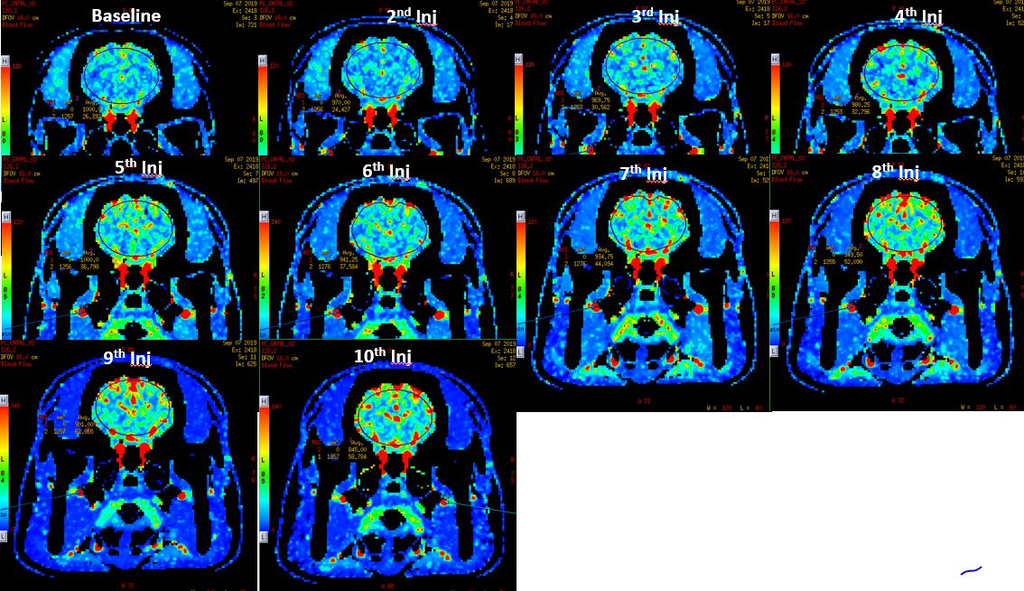

### PS map

- Slight leakage between 5th and 7th injection

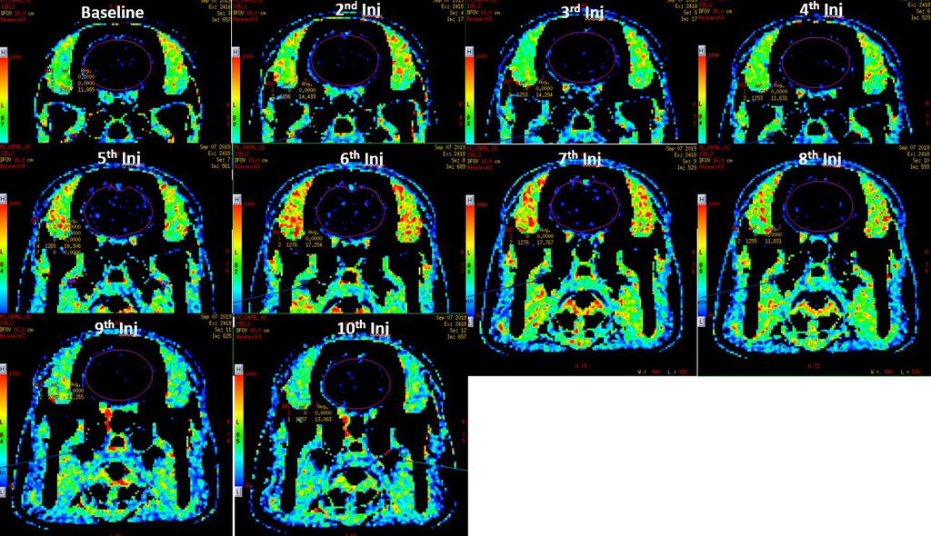

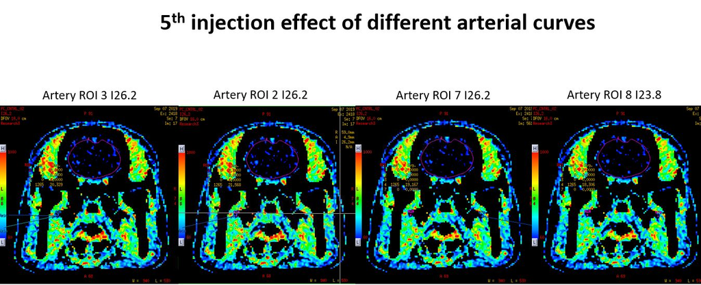

### Average

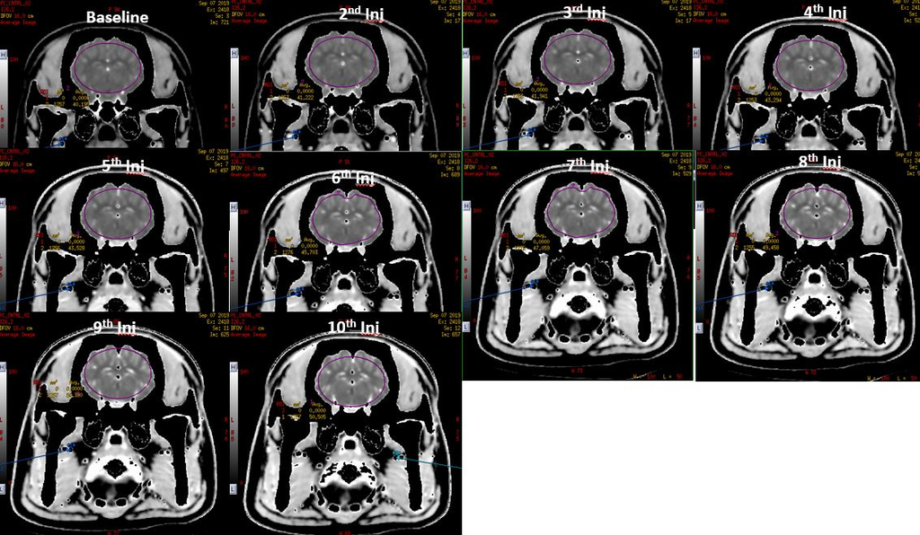

### Blood Volume

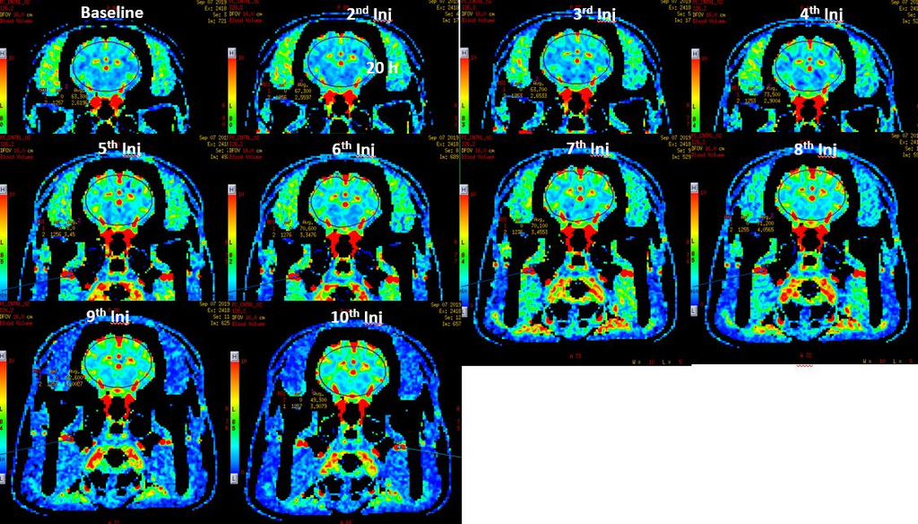

### Mean transit time

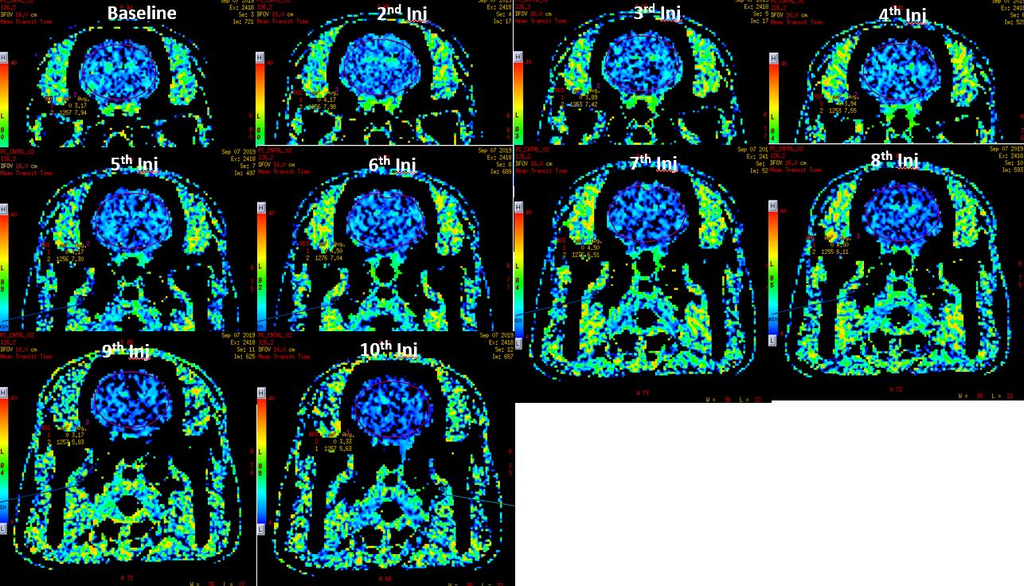

### T0

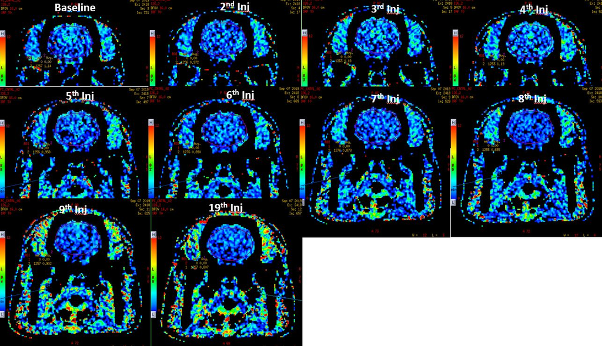